# Série Chronologique - Projet

```r
library(TSA)
library(tseries)
library(forecast)
source(file = "functions.R")
```

# Introduction

L’objet d’étude de ce projet est une série temporelle décrivant le nombre de commandes par jour d’une entreprise angevine de livraison de repas à domicile. Cette série est découpée en un jeu d’entrainement (train set) de 280 observations et un jeu de test (test set) de 21 observations. Notre objectif sera d’étudier cette série et de construire un modèle de la famille des modèles $ARMA$ afin de prédire les valeurs du jeu de test soit 21 jours.

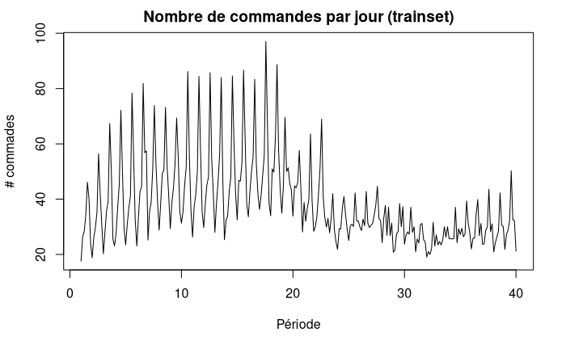

```r
data = read.csv('orders.csv')
trainset = ts(data$n_orders, start=1, end=40, frequency=7)
testset = ts(data$n_orders, start=41, end=44, frequency=7)
plot(trainset, type='l', xlab="Période", ylab="# commades", main="Nombre de commandes par jour (trainset)")
```

# Analyse visuelle

Cette série présente plusieurs caractéristiques remarquables.

La série semble composée de deux voir trois régime. Un premier lors des 18 premières semaines avant une tendance haussière, une saisonnalité très marquée et une variance relativement grande. Puis, vient 16 semaines de tendance baissière, avec une saisonnalité moins marquée et une plus faible variance. Enfin, les 5 dernières semaines semble reprendre quelque peu le schéma de premières semaine avec un tendance à la hausse, une saisonnalité marquée et une variance qui augmente.

```r
layout(matrix(c(1, 2), nrow=1, ncol=2, byrow=TRUE))
# Segmentation
t1 = 1:126; X1 = trainset[t1]
t2 = 127:246; X2 = trainset[t2]
t3 = 247:280; X3 = trainset[t3]
lm1 = lm(X1~t1)
lm2 = lm(X2~t2)
lm3 = lm(X3~t3)
plot(t1, X1, type='l', xlab="Index", ylab="# commandes", main="Segmentation de la série temporelle", xlim=c(0,length(trainset)))
lines(t2, X2, type="l", col="blue")
```

```r
lines(t3, X3, type="l", col="red")
lines(t1, lm1$coefficients[1]+ t1 * lm1$coefficients[2])
```

```r
lines(t2, lm2$coefficients[1]+ t2 * lm2$coefficients[2], col="blue")
lines(t3, lm3$coefficients[1]+ t3 * lm3$coefficients[2], col="red")
```

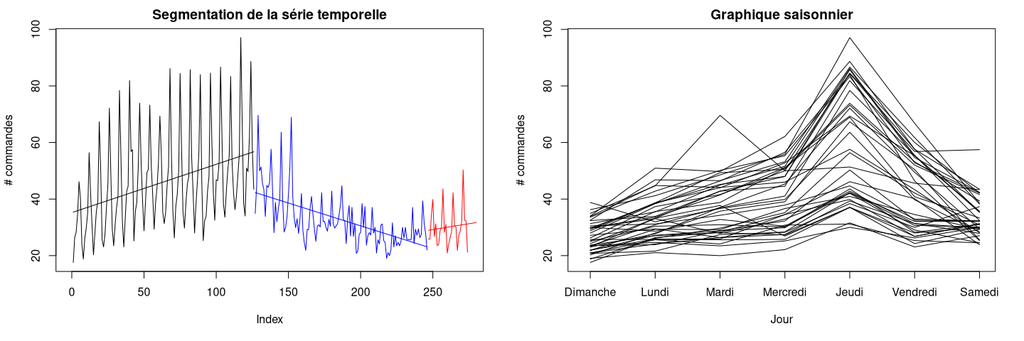

```r
# Saisonalité
seasonplot(trainset, type="l", main="Graphique saisonnier", xlab="Jour", ylab="# commandes", season.labels=c("Dimanche", "Lundi", "Mardi", "Mercredi", "Jeudi", "Vendredi", "Samedi"))
```

Les modèles $ARMA$ font l’hypothèse que la série temporelle est stationnaire (du second ordre), c’est à dire que sa moyenne et sa covariance sont invariantes par translation dans le temps. Pour rendre cette série stationnaire, nous allons utiliser plusieurs approches telles que la décomposition (partie 2) et la différentiation (partie 3). Puis nous établirons des modèles de la famille $ARIMA$ à l’aide de la fonction `auto.arima` et `checkup_res` (partie 3) avant d’évaluer nos modèles sur le jeu de données test avec des critères prédictifs (partie 4).